# R Notebook

## Data Engineer

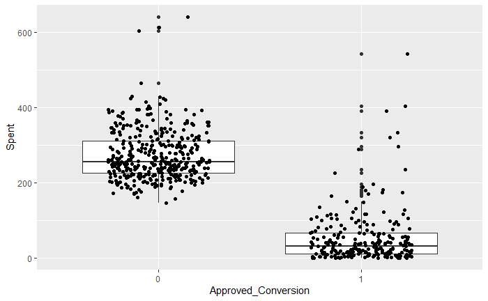

```r
ggplot(sales , aes(x = Approved_Conversion, y = Spent)) +
  geom_boxplot() +
  geom_jitter(width = 0.25,show.legend = FALSE, fill = "white")
```

```r
  # geom_smooth(method = 'lm', formula = y~x) +
  # facet_grid(~Approved_Conversion)
```

*Spent* covariant had no inverse relation with *Approved Conversion* therefore a normal random variable was added to those records in *approved conversion* where the sales convertion was effective. This provided the negative relationship of the amount spent on ads and the probability of conversion.

```r
fit <- brm(Approved_Conversion ~ age + Clicks + gender + Spent , data = sales, family = bernoulli(link = "logit"),
           prior = get_prior(Approved_Conversion ~  age + Clicks + gender + Spent , data = sales, family = binomial()),
           silent=TRUE,
           refresh = -1,)
```

```
recompiling to avoid crashing R session
```

```r
summary(fit)
```

```
 Family: bernoulli
  Links: mu = logit
Formula: Approved_Conversion ~ age + Clicks + gender + Spent
   Data: sales (Number of observations: 625)
Samples: 4 chains, each with iter = 2000; warmup = 1000; thin = 1;
         total post-warmup samples = 4000

Population-Level Effects:
          Estimate Est.Error l-95% CI u-95% CI Rhat Bulk_ESS Tail_ESS
Intercept     5.56      1.04     3.71     7.80 1.00     2580     3135
age35M39     -0.24      0.92    -1.99     1.57 1.00     1834     2294
age40M44      0.72      0.97    -1.17     2.72 1.00     1782     2089
age45M49      1.13      0.88    -0.55     2.94 1.00     1795     2112
Clicks        0.08      0.02     0.04     0.13 1.01      822      977
genderM       0.73      0.88    -0.97     2.48 1.00     1381     1571
Spent        -0.08      0.02    -0.12    -0.06 1.01      803      937

Samples were drawn using sampling(NUTS). For each parameter, Eff.Sample
is a crude measure of effective sample size, and Rhat is the potential
scale reduction factor on split chains (at convergence, Rhat = 1).
```

```r
add_spend <- function(spent){
  # First Create the input data to predict with out model - we want to predict whether or not our phone will sell

  marketing <- data.frame(age = '30-34', gender='F', Clicks = 30, Spent = spent)

  # Next, for each posterior sample from out model, predict whether or not our phone would sell at the given price. This will give a vector of 0's and 1's, did the phone sell in each posterior sample. Think of each posterior sample as a simulation.
  pp <- posterior_predict(fit, newdata=marketing)

  # Next calculate the expected return for each of these posterior simulations
  mean(spent*pp)
}
optimize(function(x) add_spend(x), c(0,200), maximum = TRUE)
```

```
$maximum
[1] 76.96055

$objective
[1] 60.26011
```

```r
#(op <- optim(20, function(x) -add_spend(x)))
```

## FB ads campaign optimization

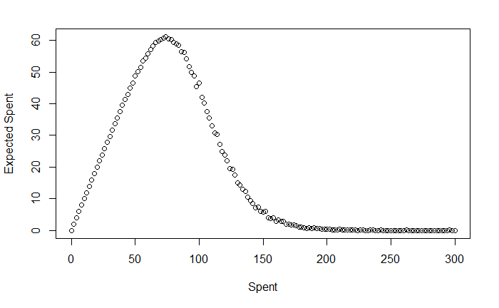

```r
x <- seq(0,300, by=2) # Listing prices to evaluate
l <- sapply(x, add_spend)
plot(x, l, xlab = "Spent", ylab = "Expected Spent")
```

This plot shows the expense function optimization limits, and confirms the optimum value of the FB ad campaign.

## Conclusions

Bayesian decision theory is aims to quantify and expected value of the given decisions in order to take best one, nonetheless data must follow Bayesian probability assumptions otherwise posterior function won’t convex naturally.